# C3GAW - Unix Introduction - BASH - Command Line

Pierre-Olivier Quirion

2019-01-22

### Background

At a high level, we have seen that computers do four things:

- run programs (system that counts)
- store data (system that stores)
- communicate with each other (IO, streams)
- interact with us (UI)

We are all familiar with **graphical user interfaces** (GUI): where a “click” translates easily into “do the thing I want”.

If you wish to do complex, purpose-specific things it helps to have a richer means of expressing your instructions to the computer. It doesn’t need to be complicated or difficult, just a vocabulary of commands and a simple grammar for using them.

This is what the shell provides - a simple language and a **command-line interface** to use it through.

### The Shell

A shell is a program like any other. What’s special about it is that its job is to run other programs rather than to do calculations itself. The most popular Unix shell is Bash, the Bourne Again SHell (so-called because it’s derived from a shell written by Stephen Bourne and because programers make these kinds of jokes).

### What does it look like?

A typical shell window looks something like this:

```bash
bash-3.2$
bash-3.2$ ls -F /
Applications/         System/
Library/              Users/
Network/              Volumes/
bash-3.2$
```

The first line shows only a **prompt**, indicating that the shell is waiting for input. Your shell may use different text for the prompt. Most importantly: when typing commands, either from these lessons or from other sources, *do not type the prompt*, only the commands that follow it.

The part that you type, `ls -F /` in the second line of the example, typically has the following structure: a **command**, some **flags** (also called **options** or **switches**) and an **argument**. Flags start with a single dash (`-`) or two dashes (`--`), and change the behaviour of a command. Arguments tell the command what to operate on (e.g. files and directories).

Next we see the output that our command produced: in this case it is a listing of files and folders in a location called `/` - we’ll cover that in the next section.

Finally, the shell prints the prompt again and waits for you to type the next command.

**In the examples for this lesson, we’ll show the prompt as `$`. Do not type `$` when typing in the commands.**

Open a shell window and try executing `ls -F /` for yourself (don’t forget that spaces and capitalization are important!). You can change the prompt too, if you like.

## Lets all connect to the *Mammouth* Supercomputer

> Open a command line terminal and log in to Mammouth.

```bash
ssh <YOUR_USERNAME>@mp2.ccs.usherbrooke.ca
# or
ssh -l <YOUR_USERNAME> mp2.ccs.usherbrooke.ca
```

For those on older windows, you can use putty:

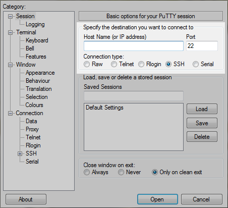

You should now be logged to *Mammouth*, the Supercomputer located at Sherbrooke University, and see this prompt:

```bash
[poq@ip17-mp2 ~]$
```

> **If you are not connected right now, please stop me! We will send the cavalry to help**

### Where am I & who am I?

You now have a terminal connected to a remote computer, but that terminal could for some reason disconnect from *Mammouth* or you could simply have a second terminal open that is connected to your laptop.

If you ever need to be certain which system a terminal you are using is connected to then use:

```
> Test the following command: $ hostname
```

You might also what to know who you are!

```
> Test the following command: $ whoami
```

> What are these two commands telling you?

# Exploring the File system

First, let’s find out where we are by running a command called `pwd` (which stands for “print working directory”). Directories are like *places*; Linux’s version of “Folders”. At any moment in time, while using the shell, we are in exactly one place, called our **current working directory**. Commands mostly read and write files in the current working directory, i.e. “here”, so knowing where you are before running a command is important. `pwd` shows you where you are:

```bash
$ pwd
/home/guest33
```

Here, the computer’s response is `/home/guest33`, which is the **home directory**, what is your home directory path?

### Home Directory Variation

The home directory path will look different on different operating systems. On OSX it may look like `/Users/guest33`, and on Windows it will be similar to `C:\Documents and Settings\guest33` or `C:\Users\guest33`.

To understand what a “home directory” is, let’s have a look at how the file system as a whole is organized. For the sake of this example, we’ll be illustrating the filesystem with the user *myuser* seen in the image below. After this illustration, you’ll be learning commands to explore your own filesystem, which will be constructed in a similar way, but not exactly identical.

Here is what the *myuser* filesystem looks like:

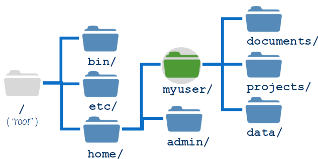

At the top is the **root directory** that holds everything else. We refer to it using a slash character, `/`, on its own; this is the leading slash in `/home/myuser`.

Inside that directory are several other directories:  
- `bin` (which is where some built-in programs are stored)  
- `etc` (for miscellaneous, typically configuration files)  
- `home` (where users’ personal directories are located)

We know that our current working directory `/home/myuser` is stored inside `/home` because `/home` is the first part of its name. Similarly, we know that `/home` is stored inside the root directory `/` because its name begins with `/`.

Now let’s learn the command that will let us see the contents of our own filesystem. We can see what’s in our home directory by running `ls`, which stands for *listing*:

```bash
$ hostname
ip15
$ ls
projects  scratch c3g_ws
```

(you might have an different hostname than *ip15* since *Mammouth* has more than one log-in node.)

### Create a directory

Let’s create a new directory called `RNAseq_workshop` using the command `mkdir RNAseq_workshop` (which has no output):

```bash
$ mkdir RNAseq_workshop
```

As you might have guessed from its name, `mkdir` means “make directory”. Since `RNAseq_workshop` is a relative path (i.e., does not have a leading slash, like `/what/ever/RNAseq_workshop`), the new directory is created in the current working directory:

```bash
$ ls -l
```

```bash
drwxr-xr-x 2 guest11 guests 4096 Jan 11 11:04 projects
drwxr-xr-x 2 guest11 guests 4096 Jan 11 11:04 c3g_ws
drwxr-xr-x 2 guest11 guests 4096 Jan 18 15:29 RNAseq_workshop
lrwxrwxrwx 1 guest11 guests   16 Jan 11 11:04 scratch -> /scratch/guest11
```

We have added a flag, -l to list the folder content in a *long list* format; extra information is also included and the formating is one file per line.

> 1. Don’t use whitespaces.

> Whitespaces can make a name more meaningful but since whitespace is used to break arguments on the command line it is better to avoid them in names of files and directories. You can use `-` or `_` instead of whitespace.
> 2. Don’t begin the name with `-` (dash).

> Commands treat names starting with `-` as options.

Since we’ve just created the `RNAseq_workshop` directory, there’s nothing in it yet:

```bash
$ ls -l RNAseq_workshop
```

### Create a text file

Let’s change our working directory to `RNAseq_workshop` using `cd`, then run a text editor called nano to create a file called `draft.txt`:

There are several ways to create a file. One way to do it is to use the nano editor. nano is simple to use and is available everywhere on Compute Canada.

```bash
$ cd RNAseq_workshop
$ pwd
/home/guest33/RNAseq_workshop
$ nano draft.txt
```

Note: nano main commands are displayed at the bottom of the screen. The ^ symbol corresponds to the control key on MAC keyboards and Ctrl on PC keyboards. ^+O will save the file, ^+X will exit nano and ^+G will display the help menu. Use ^+C if you are stuck or lost. It will cancel or quit anything you are doing.

You can do most common things in nano that you can do in another editor, such as typing or copying text.

The terminal has commands to print and/or navigate the contents of files without the use of an editor, like the `cat` and `less` commands.

> what is the result of the following commands?

```bash
cat draft.txt
```

and

```bash
less draft.txt
```

If you are stuck in the `less` program, just type `q`.

> **Q.** What happens if you type `cd` on its own, without giving a directory?

**Solution (click-here)**

You can see where you are taken by typing pwd

```bash
$ cd
$ pwd
/home/poq
```

### Getting help

`ls` and the other commands we are learning have lots of **flags**. There are two common ways to find out how to use a command and what flags it accepts:

1. We can pass a `--help` flag to the command, such as

```bash
$ ls --help
$ cat --help
...
```

2. We can read its manual with `man`, such as

```bash
$ man ls
```

**Depending on your environment you might find that only one of these works (either `man` or `--help`).**

If your are stuck in the *man* page, just type `q`.

## What else is stored on *Mammouth*

```bash
$ ls -F c3g_ws
def-poq/
```

Now that we know the `def-poq` directory is located on our `c3g_ws/` directory, we can do two things.

> **Are there people with their own account that do not see def-poq in their `c3g_ws` folder? Run the following command please:**

> ```bash
> mkdir c3g_ws
> ln -s /project/6019104 c3g_ws/def-poq
> ```

Now, we can look at its contents, using the same strategy as before, passing a directory name to `ls`:

```bash
$ ls -F c3g_ws/def-poq
poq/  workshop/
```

Second, we can actually change our location to a different directory, so we are no longer located in our home directory.

Let’s say we want to move to the `workshop` directory we saw above. We can use the following series of commands to get there:

```bash
$ cd c3g_ws
$ cd def-poq
$ cd workshop
$ cd pub
```

```bash
$ pwd
```

```bash
/home/poq/c3g_ws/def-poq/workshop/pub
```

```bash
$ ls -F
C3GAW_08_2018/  cedar/
```

We now know how to go down the directory tree, but how do we go up, back where we are from? We might try the following:

```bash
$ cd workshop
-bash: cd: workshop: No such file or directory
```

But we get an error! Why is that?

With our methods so far, `cd` can only see sub-directories inside your current directory. There are different ways to see directories above your current location; we’ll start with the simplest.

There is a shortcut in the shell to move up one directory level that looks like this:

```bash
$ cd ..
```

`..` is a special directory name meaning “the directory containing this one”, or more succinctly, the **parent** of the current directory. Sure enough, if we run `pwd` after running `cd ..`, we’re back in `/home/poq/c3g_ws/def-poq/workshop`:

```bash
$ pwd
/home/poq/c3g_ws/def-poq/workshop
```

So far, when specifying directory names, or even a directory path (as above), we have been using **relative paths**. When you use a relative path with a command like `ls` or `cd`, it tries to find that location from where we are, rather than from the root of the file system.

However, it is possible to specify the **absolute path** to a directory by including its entire path from the root directory, which is indicated by a leading slash. The leading `/` tells the computer to follow the path from the root of the file system, so it always refers to exactly one directory, no matter where we are when we run the command.

```bash
$ pwd
/home/poq
$ cd /home/poq/c3g_ws/def-poq/workshop
```

Run `pwd` and `ls -F` to ensure that we’re in the directory we expect.

### One More Shortcut

The shell interprets the character `~` (tilde) at the start of a path to mean “the current user’s home directory”. For example, if your home directory is `/home/guest33`, then `~/c3g_ws` is equivalent to `/home/guest33/c3g_ws`. This only works if it is the first character in the path: `here/there/~/elsewhere` is *not* `here/there/home/guest33/elsewhere`.

> **Q.** Starting from `/home/guest33/c3g_ws/`, which of the following commands could guest33 use to navigate to the home directory, which is `/home/guest33`?
> 1. `cd .`
> 2. `cd /`
> 3. `cd /Users/guest33`
> 4. `cd ../..`
> 5. `cd ~`
> 6. `cd home`
> 7. `cd ~/data/..`
> 8. `cd`
> 9. `cd ..`

> **Solution (click-here)**

> 1. No: `.` stands for the current directory.  
> 2. No: `/` stands for the root directory.  
> 3. No: guest33’s home directory is `/home/guest33`.  
> 4. No: this goes up two levels, i.e. ends in `/home`.  
> 5. Yes: `~` stands for the user’s home directory, in this case `/home/guest33`.  
> 6. No: this would navigate into a directory `home` in the current directory if it exists.  
> 7. Yes: unnecessarily complicated, but correct.  
> 8. Yes: shortcut to go back to the user’s home directory.  
> 9. Yes: goes up one level.

## Removing files and directories

Lets go back to the directory and file we have created before.

```bash
$ cd
$ pwd
/home/guest33
$ ll
drwxr-xr-x 2 guest11 guests 4096 Jan 11 11:04 c3g_ws
drwxr-xr-x 2 guest11 guests 4096 Jan 11 11:04 projects
drwxr-xr-x 2 guest11 guests 4096 Jan 18 15:29 RNAseq_workshop
lrwxrwxrwx 1 guest11 guests   16 Jan 11 11:04 scratch -> /scratch/guest11
$ cd RNAseq_workshop
$ ls
draft.txt
$ rm draft.txt
```

This command removes files (`rm` is short for “remove”). If we run `ls` again, its output is empty once more, which tells us that our file is gone:

```bash
$ ls
```

Let’s re-create that file and then move up one directory to `/home/guest11` using `cd ..`:

```bash
$ pwd
/home/guest11/RNAseq_workshop
$ nano draft.txt
$ ls
draft.txt
$ cd ..
$ pwd
/home/guest11
```

If we try to remove the entire `RNAseq_workshop` directory using `rm RNAseq_workshop`, we get an error message:

```bash
$ rm RNAseq_workshop
rm: cannot remove 'RNAseq_workshop': Is a directory
```

This happens because `rm` by default only works on files, not directories.

To really get rid of `RNAseq_workshop`, we must also delete the file `draft.txt`. We can do this with the [recursive](https://en.wikipedia.org/wiki/Recursion) option for `rm`:

```bash
$ rm -r RNAseq_workshop
```

### File manipulations

Deleting, copying and removing files is fairly easy. `cp` and `mv` work similarly, except `cp` will create a copy of a file while `mv` will move the file and delete the original.  
You need to specify the original file and the destination. The destination can be a directory (current or a different one) or another file name. Remember that the current directory is `.` and the parent directory `..`

For instance `mv draft.txt ../` will move a file to the parent directory. `rm` will remove a file. Be careful when you are using it as there is no way to recover it!

Let’s recreate the `RNAseq_workshop` Directory

I can recreate a `draft.txt` file in my home and play with it a bit.

```bash
$ nano drsft.txt
```

oups I wanted it to be called draft!

```bash
$ mv drsft.txt draft.txt
```

oups I wanted to have it in the `RNAseq_workshop` Directory

```bash
$ cp draft.txt RNAseq_workshop
$ ls
draft.txt
$ ls RNAseq_workshop
draft.txt
$ rm draft.txt
```

### Exercise

Let’s copy the workshop material to the `RNAseq_workshop` folder. We have all the class material at the followig PATH `~/c3g_ws/def-poq/workshop/pub/C3GAW_08_2018/RNAseq_TestData`

> **Q.** copy the directory and its content (recursively) into the `~/RNAseq_workshop` directory created in the previous exercise. To be able to see what is going on, activate the verbose flag of the copy command.

**Solution (click-here)**

First, try to find the verbose flag with either `man cp` or `cp --help`

Then copy the directory with both the verbose and the recursive flag in your home

```bash
cp -r -v ~/c3g_ws/def-poq/workshop/pub/C3GAW_08_2018/RNAseq_TestData ~/RNAseq_workshop/.
```

Note that we used an absolute path to copy the directory so the working directory does not matter.

### Environment variables

An environment variable can be thought of as an alias or shortcut for some content. It is created by assigning a content or value to a variable name.  
For instance `VAR=1` will create a variable called `VAR` containing the value `1`. Adding `$` sign at the beginning of the variable will return its *content*. You can print the content of a variable using the command `echo`

> Create a variable called `MY_VAR` and set it to 2. Display its value. Change the content of `MY_VAR` to `HELLO,WORLD` and display its value again.

**Solution (click here)**

```bash
  MY_VAR=2
  echo $MY_VAR
  MY_VAR=HELLO,WORLD #or MY_VAR="HELLO,WORLD"
  echo $MY_VAR
```

Bash can be finicky about spaces, especially when setting a variable value.

**Some special environment variables**

- $HOME –> your home directory
- $PATH –> where all the scripts you can execute are stored (like `ls`, `rm`, etc.). If the script is not in the $PATH, you need to use its full or relative path to run it.
- $HOSTNAME –> the current machine
- $USER –> your username
- Many others exist, you can type `env` to see all the variables set in your environment
- One env var that you will see a lot is $MUGQIC_PIPELINES_HOME

### Stream redirection

Sometimes, you want to redirect the output (stdout) of a process to a file (it is connected to your screen by default). This can be accomplished by adding `> output.txt`.  
For instance, `echo HELLO,WORLD` will print `HELLO,WORLD` to your terminal (i.e. the default sdtout redirection), but `echo HELLO,WORLD > hello_world.txt` will print `HELLO,WORLD` into a new file called `hello_world.txt`. `>` is a tool to redirect a processes stdout to a file. Note that you can also use `>>` if you want to append data to a file instead of loosing its old content.

> Print the content of the current directory into a file called `log.txt`. Display the content of the file.

**Solution (click here)**

```bash
ls > log.txt
cat log.txt
```

**This tutorial is heavily influenced by the software carpentry Unix Shell introduction, found at http://swcarpentry.github.io/shell-novice/ which regulated by a [Creative Commons license](https://creativecommons.org/licenses/by/4.0/).**